# crosnma for synthesize Cross-design evidence and Cross-format data using Network Meta-Analysis

Tasnim Hamza and Georgia Salanti

2021-06-21

```r
library(crosnma)
library(rjags)
load.module('mix')
```

```
#> module mix loaded
```

# 1 Introduction

In network meta-analysis we synthesize all relevant available evidence about health outcomes from competing treatments. That evidence might come from different study designs and in different formats: from non-randomized studies (NRS) or randomized controlled trials (RCT) as individual participant data (IPD) or as aggregate data (AD). We establish the (`crosnma`) package to utilize all available evidence.

This document demonstrates how to use `crosnma` to perform a synthesize from cross-design evidence and cross-format data. The package has been developed for conducting Bayesian network meta-analysis and meta-regression. All models are implemented in JAGS.

We describe the workflow within the package using a worked example about relapsing remitting multiple sclerosis (RRMS). The primary outcome is the occurrence of relapses in two years (binary outcome, 0/1). In the analysis, the outcome will be expressed as odds ratio (OR). The aim is to compare the efficacy of four treatments using the data from 6 different studies in different formats and different designs.

# 2 The synthesis model of individual participant data (IPD) and aggregate data (AD)

We introduce the model to synthesis RCT and NRS where each one can be either available on individual-level (IPD) or/and on study-level (AD). We describe the four synthesis models for network meta-regression. However, we can run network meta-analysis by declining covariate terms from the models. Let’s begin by setting the notations that will be used in the description of the four models.

| Notation | Description | Argument in `crosnma.model()` |
| --- | --- | --- |
| $i=1, ..., np_j$ | participant id |  |
| $j=1, ..., ns$ | study id |  |
| $k=1, ..., K$ | treatment index |  |
| $ns_{IPD}, ns_{AD}, ns_{RCT}, ns_{NRS}$ | the number of studies. The index refers to the design or format of the study |  |
| $y_{ijk}$ | binary outcome (0/1) | `outcome` |
| $p_{ijk}$ | probability of the event to occur |  |
| $r_{jk}$ | the number of events per arm | `outcome` |
| $n_{jk}$ | the sample size per arm | `n` |
| $b$ | the study-specific reference | * |
| $u_{j}$ | The treatment effect of the study-specific reference |  |
| $\delta_{jk}$ | log(OR) of treatment k relative to $b$ |  |
| $x_{ijk}$ | the covariate | `covariate` |
| $\bar{x}_{j}$ | the mean covariate for study $j$ |  |
| $d_{Ak}$ | the basic parameters. Here, $d_{AA}=0$ when A set as the reference in the network | use `reference` to assign the reference treatment |
| $z_j$ | study characteristics to estimate the bias probability $\pi_j$ | `bias.covariate` |
| $w_j$ | inflation factor of variance for the NRS estimates | the element `var.infl` in `run.nrs` |
| $\vartheta_j$ | mean shift of the NRS estimates | the element `mean.shift` in `run.nrs` |

*If the reference in the network ($A$) is available on the study, it is assigned automatically to that reference. If not, it is assigned to the first alphabetically ordered treatment on the study.

## 2.1 Naive synthesis

We synthesis the evidence from RCT and NRS without acknowledging the differences between them. We combine the IPD data from RCT and NRS in one model and we do the same in another model with the AD information. Then, we combine the estimates from both parts as described in Section 2.5. See the full details in Section 2.2.1 in Hamza T (2021).

**model IPD only**

$$y_{ijk} \sim Bernoulli(p_{ijk})$$
$$\begin{equation}
logit(p_{ijk}) =
\begin{cases}
u_j +\beta_{0,j} x_{ijk} & \text{if $k=b$}\\
u_j +\delta_{jk} + (\beta_{0,j}+\beta^w_{1,jk}) x_{ijk}+
(\beta^B_{1,jk}-\beta^w_{1,jk}) \bar{x}_{.j} & \text{if $k≠b$}
\end{cases}
\end{equation}$$

**model AD only**

$$r_{jk} \sim Binomial(p_{jk},n_{jk})$$
$$\begin{equation}
logit(p_{jk}) =
\begin{cases}
u_j & \text{if $k=b$}\\
u_j +\delta_{jk} +\beta^B_{1,jk} \bar{x}_{j} & \text{if $k≠b$}
\end{cases}
\end{equation}$$

## 2.2 Using non-randomized studies (NRS) as a prior

First we estimate the relative treatment effects using only the NRS (use `run.nrs` in `crosnma.model()` to control this process). Second, we use the NRS estimates ($\hat{d}^{NRS}_{Ak},\hat{V}^{NRS}_{Ak}$) as a prior information for the basic parameters of RCT data, $d_{Ak} \sim N(\hat{d}^{NRS}_{Ak},\hat{V}^{NRS}_{Ak})$. To control the NRS influence in the RCT estimates, we can either inflate the NRS variance by dividing by $w_j$ (the inflated variance is $\hat{V}^{NRS}_{Ak}/w_j$) or shift the NRS means by $\vartheta$.

## 2.3 Bias-adjusted model 1

We incorporate the risk of bias (RoB) into the IPD and the AD models by adding the bias term $\gamma_j R_j$ to both models as follows:

**model IPD only**

$$y_{ijk} \sim Bernoulli(p_{ijk})$$
$$\begin{equation}
logit(p_{ijk}) =
\begin{cases}
u_j +\beta_{0,j} x_{ijk} & \text{if $k=b$}\\
u_j +\delta_{jk} + (\beta_{0,j}+\beta^w_{1,jk}) x_{ijk}+
(\beta^B_{1,jk}-\beta^w_{1,jk}) \bar{x}_{.j}+\gamma_j R_j & \text{if $k≠b$}
\end{cases}
\end{equation}$$

**model AD only**

$$r_{jk} \sim Binomial(p_{jk},n_{jk})$$
$$\begin{equation}
logit(p_{jk}) =
\begin{cases}
u_j & \text{if $k=b$}\\
u_j +\delta_{jk} +
\beta^B_{1,jk} \bar{x}_{j}+\gamma_j R_j & \text{if $k≠b$}
\end{cases}
\end{equation}$$

The bias indicator

$$R_j \sim Bernoulli(\pi_j)$$

## 2.4 Bias-adjusted model 2

**model IPD only**

$$y_{ijk} \sim Bernoulli(p_{ijk})$$
$$\begin{equation}
logit(p_{ijk}) =
\begin{cases}
u_j +\beta_{0,j} x_{ijk} & \text{if $k=b$}\\
u_j +\theta_{jk} + (\beta_{0,j}+\beta^w_{1,jk}) x_{ijk}+
(\beta^B_{1,jk}-\beta^w_{1,jk}) \bar{x}_{j} & \text{if $k≠b$}
\end{cases}
\end{equation}$$

**model AD only**

$$r_{jk} \sim Binomial(p_{jk},n_{jk})$$
$$\begin{equation}
logit(p_{jk}) =
\begin{cases}
u_j & \text{if $k=b$}\\
u_j +\theta_{jk} +\beta^B_{1,jk} \bar{x}_{j} & \text{if $k≠b$}
\end{cases}
\end{equation}$$

## 2.5 Assumptions about the model parameters

The table below summarizes the different assumptions implemented in the package about combining the parameters in the four model described above.

| Parameter | Assumptions | Argument in `crosnma.model()` |
| --- | --- | --- |
| relative treatment effect ($\delta_{jk}$) | Random-effects: $\delta_{jk} \sim N(d_{Ak}-d_{Ab}, \tau_\delta^2)$ | `trt.effect='random'` |
|  | Common-effect: $\delta_{jk}=d_{Ak}-d_{Ab}$ | `trt.effect='common'` |
| Covariate effect $\beta_{0, j}$ | Independent effects: $\beta_{0, j} \sim N(0, 10^2)$ | `reg0.effect='independent'` |
|  | Random-effects: $\beta_{0,j} \sim N(B_0, \tau_{\beta_0})$ | `reg0.effect='random'` |
| Within-study covariate-treatment interaction ($\beta_{1, jk}^W$) | Random-effects: $\beta_{1, jk}^W \sim N(B_{1, Ak}^W-B_{1, Ab}^W, \tau_{\beta_1^W})$ | `regw.effect='random'` |
|  | Common-effect: $\beta_{1,jk}^W = B_{1, Ak}^W-B_{1, Ab}^W$ | `regw.effect='common'` |
| Between-study covariate-treatment interaction ($\beta_{1, jk}^B$) | Random-effects: $\beta_{1,jk}^B \sim N(B_{1, Ak}^B-B_{1, Ab}^B, \tau_{\beta_1^B})$ | `regb.effect='random'` |
|  | Common-effect: $\beta_{1,jk}^B = B_{1, Ak}^B-B_{1, Ab}^B$ | `regb.effect='common'` |
| bias-adjusted relative treatment effect ($\theta_{jk}$) | Random-effects: $\theta_{jk} \sim (1-\pi_j)N(d_{Ak}-d_{Ab}, \tau_\delta^2) + \pi_jN(d_{Ak}-d_{Ab}+\gamma_j, \tau_\delta^2+\tau_\gamma^2)$ | `trt.effect='random'` |
| Bias effect ($\gamma_{j}$) | Random-effects: $\gamma_{j} \sim N(\Gamma, \tau_{\gamma})$ | `bias.effect='random'` |
|  | Common-effect: $\gamma_{j} = \Gamma$ | `bias.effect='common'` |
| Bias probability ($\pi_j$) | $\pi_j \sim Beta(a,b)$ |  |
|  | $\pi_j = a+bz_j$ |  |

# 3 Application to the analysis of a network of studies comparing drugs for relapsing-remitting multiple sclerosis

Both datasets have 6 studies. These studies are either available as study-level data `std.data` (2 studies) or as individual participant data `prt.data` (four studies). The `prt.data` have been manipulated by re-sampling from the original data set. Three of the `prt.data` are RCTs and one comes from an observational study (NRS). The two `std.data` are RCTs. Both datasets consist of four drugs which are anonymized.

The `prt.data` contains 2950 rows, each row refers to a participant in the study. We display the first few rows of the data set:

```r
head(prt.data)
```

```
#>   study outcome trt design age sex bias year
#> 1     1       0   D    rct  20   1  low 2002
#> 2     1       0   D    rct  29   0  low 2002
#> 3     1       0   D    rct  35   0  low 2002
#> 4     1       0   D    rct  38   0  low 2002
#> 5     1       0   D    rct  37   0  low 2002
#> 6     1       0   D    rct  32   0  low 2002
```

For each participant, we have information for the occurrence of the relapses (0=no, 1=yes) `outcome`, the treatment label `trt`, the age (in years) `age` and sex (0 = Female, 1 = Male) `sex` of the participant. The following columns are set on study-level (it is repeated for each participant of the study): the study id `study`, the design of the study (needs to be either rct or nrs) `design`, the risk of bias on each study (can be set as low, high or unclear) `bias` and the year of publication `year`.

We display the full study-level data:

```r
head(std.data)
```

```
#>   study outcome   n trt design  age sex    bias year
#> 1     1      19  25   A    rct 34.3 0.2     low 2010
#> 2     1      11  25   C    rct 34.3 0.3     low 2010
#> 3     2      97 126   A    rct 30.0 0.4 unclear 2015
#> 4     2      89 125   C    rct 30.0 0.5 unclear 2015
```

For all studies, we provide the following information on each arm level: the total number of participants `n` and the number of those who relapsed `outcome`, the treatment label `trt`. At study-level, we have the study id `study`, the design of the study `design`, the mean age `age`, the percentage of males `sex`, the risk of bias on the study `bias` and the year of publication `year`.

**Check network connectivity**

The network should be checked for its connectivity before running the analysis. This is a vital step as the model will run even if the network is not connected.

*Network plot*

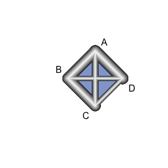

```r
netplot(prt.data,std.data)
```

**Network characteristics**

In the following table, we summarize the number of studies from each design and each data format:

```r
knitr::kable(ns.tab(prt.data,std.data))
```

|  | IPD | AD |
| --- | --- | --- |
| RCT | 3 | 2 |
| NRS | 1 | 0 |

# 4 R implementation

There are two steps to run the NMA/NMR model. The first step is to create JAGS model using `crosnma.model()` which creates the JAGS code and the data. In the second step, the output of that function will be used in `crosnma.run()` to run the analysis through JAGS (Plummer 2003).

## 4.1 Naïve synthesis

### 4.1.1 Naïve network meta-analysis

**Set up JAGS model**

```r
# jags model: code+data
 mod1 <- crosnma.model(prt.data=prt.data,
                   std.data=std.data,
                   trt=c('trt','trt'),
                   study=c('study','study'),
                   outcome=c('outcome','outcome'),
                   n='n',
                   design=c('design','design'),
                   trt.effect='random',
                   reference='A',
                   method.bias = 'naive'
                    )
```

**Run JAGS**

Next, we fit the NMA model using `crosnma.run()`which requires us to set the number of adaptations, iterations, thinning and chains.

```r
# run jags
jagsfit1 <- crosnma.run(model=mod1,
                        n.adapt = 20,
                        n.iter=100,
                        n.burnin = 40,
                        thin=1,
                        n.chains=2)
```

```
#> NOTE: Stopping adaptation
```

**Output**

*Table of estimates*

We summarize the estimated parameters in the following table.

```r
knitr::kable(summary(jagsfit1,expo=T))
```

|  | Mean | SD | 2.5% | 50% | 97.5% | Rhat | n.eff |
| --- | --- | --- | --- | --- | --- | --- | --- |
| d.A | 1.000 | 1.000 | 1.000 | 1.000 | 1.000 | NaN | 0 |
| d.B | 0.858 | 2.026 | 0.225 | 0.814 | 3.217 | 0.999 | 108 |
| d.C | 1.472 | 1.803 | 0.393 | 1.480 | 4.816 | 0.996 | 100 |
| d.D | 0.404 | 2.198 | 0.085 | 0.399 | 2.239 | 0.995 | 124 |
| tau | 0.995 | 0.343 | 0.468 | 0.924 | 1.824 | 1.037 | 40 |

The estimated parameters are: exp(d.B) which is the estimated OR of B vs A, exp(d.C) and exp(d.D) are the OR of C and D relative to A, respectively. tau refers to the estimates of the heterogeneity standard deviation in the relative treatment effect across studies.

*Trace plot of estimates* We need also to check the convergence of the MCMC chains, for example, by visually inspecting the trace plot.

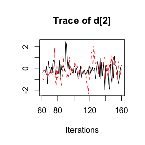

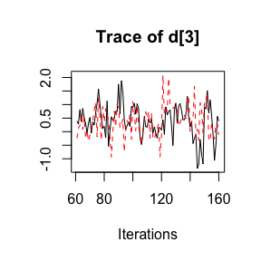

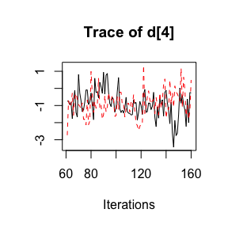

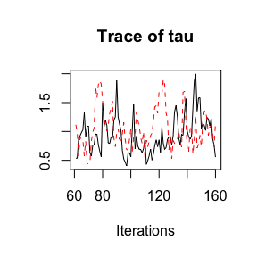

```r
coda::traceplot(jagsfit1$samples)
```

### 4.1.2 Naïve network meta-regression

In this part, we run NMR model by adding age as a covariate from both datasets. We set a list of 2 covariates in `prt.data` and `std.data`, respectively, `covariate=list(c('age'),c('age'))`. The first element in the list indicates the names of the covariate column in `prt.data` and the second element refers to the corresponding names in `std.data`.

**Set up JAGS model**

```r
# jags model: code+data
mod2 <- crosnma.model(prt.data=prt.data,
                   std.data=std.data,
                   trt=c('trt','trt'),
                   study=c('study','study'),
                   outcome=c('outcome','outcome'),
                   n='n',
                   design=c('design','design'),
                   reference='A',
                   trt.effect='random',
                   #----------  meta-regression ----------
                   covariate = list(c('age'),c('age')),
                   split.regcoef = F,
                   #---------- bias adjustment ----------
                   method.bias='naive'
                   )
```

**Run JAGS**

The MCMC is run under the same set up as in the naive model.

```r
# run jags
jagsfit2 <- crosnma.run(model=mod2,
                        n.adapt = 20,
                        n.iter=100,
                        n.burnin = 40,
                        thin=1,
                        n.chains=2)
```

```
#> NOTE: Stopping adaptation
```

**Output**

*Table of estimates*

```r
knitr::kable(summary(jagsfit2))
```

|  | Mean | SD | 2.5% | 50% | 97.5% | Rhat | n.eff |
| --- | --- | --- | --- | --- | --- | --- | --- |
| b_1 | 1.010 | 1.039 | 0.927 | 1.011 | 1.094 | 1.066 | 200 |
| d.A | 1.000 | 1.000 | 1.000 | 1.000 | 1.000 | NaN | 0 |
| d.B | 0.700 | 1.692 | 0.235 | 0.675 | 1.751 | 1.283 | 41 |
| d.C | 0.524 | 1.691 | 0.241 | 0.551 | 1.301 | 1.572 | 17 |
| d.D | 0.162 | 1.810 | 0.038 | 0.194 | 0.336 | 1.891 | 135 |
| tau | 0.465 | 0.437 | 0.032 | 0.314 | 1.728 | 1.889 | 8 |
| tau.b_1 | 0.052 | 0.038 | 0.010 | 0.039 | 0.158 | 1.089 | 52 |

Here, we additionally get the estimate of b_1 which indicates the mean effect of age and tau.b_1 which refers to the heterogeneity standard deviation in the effect of age across studies.

*Trace plot of estimates*

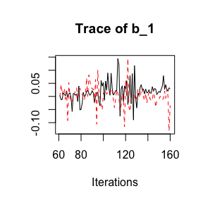

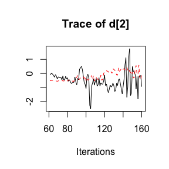

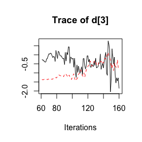

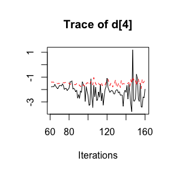

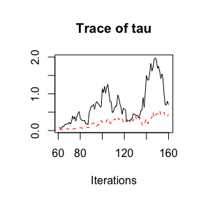

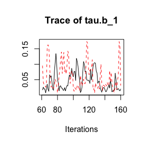

```r
coda::traceplot(jagsfit2$samples)
```

## 4.2 Using non-randomized studies (NRS) as a prior

To combine both designs, we use NRS evidence to construct a prior for the relative treatment effects, and the RCT to form the likelihood, see Section 2.2.2 in (Hamza T 2021).

**Set up JAGS model**

In this case, two additional arguments are needed to control combining RCT and NRS.

1. We indicate using NRS as prior by setting `method.bias='prior'`.
2. That means we need to run NMA with only NRS data. This requires the following MCMC settings: the number of adaptations, iterations, burn-ins, thinning and chains, assigned to `run.nrs`.

In this method, the prior for the basic parameters is set to a normal distribution that is either a minimally informative prior `d~dnorm(0, 1e-4)` (for those comparisons for which we don’t have NRS ) or the NRS mean and variance of the effects estimated in the NRS. The mean can be shifted by `mean.shift` to reflect the potential bias in NRS and/or the variance can be inflated by `var.infl` to control the influence of NRS on the final estimation. Both should be provided in `run.nrs`.

```r
# jags model: code+data
mod3 <- crosnma.model(prt.data=prt.data,
                   std.data=std.data,
                   trt=c('trt','trt'),
                   study=c('study','study'),
                   outcome=c('outcome','outcome'),
                   n='n',
                   design=c('design','design'),
                   reference='A',
                   trt.effect='random',
                   #---------- bias adjustment ----------
                   method.bias='prior',
                   run.nrs=list(n.adapt = 10,
                                n.iter=5000,
                                n.burnin = 400,
                                thin=1,
                                n.chains=2))
```

```
#> The data is analyzed assuming the studies has the same design
#>
```

**Run JAGS**

```r
# run jags
jagsfit3 <- crosnma.run(model=mod3,
                        n.adapt = 20,
                        n.iter=100,
                        n.burnin = 40,
                        thin=1,
                        n.chains=2)
```

```
#> NOTE: Stopping adaptation
```

**Output**

*Table of estimates*

```r
knitr::kable(summary(jagsfit3))
```

|  | Mean | SD | 2.5% | 50% | 97.5% | Rhat | n.eff |
| --- | --- | --- | --- | --- | --- | --- | --- |
| d.A | 1.000 | 1.000 | 1.000 | 1.000 | 1.000 | NaN | 0 |
| d.B | 1.001 | 3.218 | 0.120 | 0.977 | 10.573 | 1.017 | 200 |
| d.C | 1.308 | 2.519 | 0.244 | 1.345 | 8.240 | 1.016 | 152 |
| d.D | 0.305 | 3.929 | 0.022 | 0.316 | 3.135 | 1.005 | 357 |
| tau | 1.335 | 0.366 | 0.645 | 1.344 | 1.933 | 1.039 | 96 |

*Trace plot of estimates*

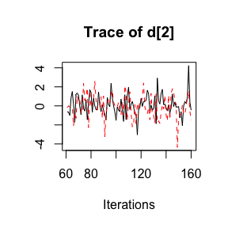

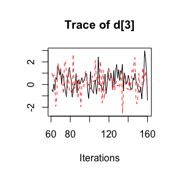

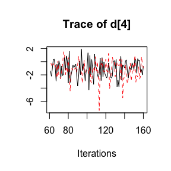

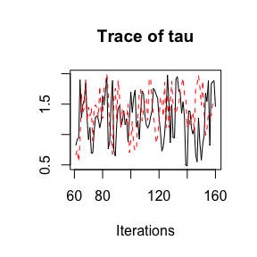

```r
coda::traceplot(jagsfit3$samples)
```

## 4.3 Bias-adjusted model 1

In this part, the overall relative treatment effects are estimated from both NRS and RCT with adjustment to study-specific bias following the method introduced by (Dias et al. 2010) and extended here; see also Section 2.3 above.

**Set up JAGS model**

We provide the name of the bias variable `bias=c('bias','bias')` in `prt.data` and `std.data`, respectively. The first element of the vector refers to the column name of bias in `prt.data` and the second in `std.data`. By default, the effect of bias is assumed to be additive `bias.type='add'` and equal across studies `bias.effect='common'`.

```r
# jags model: code+data
mod4 <- crosnma.model(prt.data=prt.data,
                   std.data=std.data,
                   trt=c('trt','trt'),
                   study=c('study','study'),
                   outcome=c('outcome','outcome'),
                   n='n',
                   design=c('design','design'),
                   reference='A',
                   trt.effect='random',
                   #---------- bias adjustment ----------
                   method.bias='adjust1',
                   bias=c('bias','bias'),
                   bias.type='add',
                   bias.effect='common',
                   #---------- assign a prior ----------
                   prior=list(tau.trt='dunif(0,3)',
                                 pi.high.rct='dbeta(5,1)',
                                 pi.low.rct='dbeta(1,20)',
                                 pi.high.nrs='dbeta(30,1)',
                                 pi.low.nrs='dbeta(1,2)'
                                  )
                  )
```

**Run JAGS**

```r
# run jags
jagsfit4 <- crosnma.run(model=mod4,
                       n.adapt = 20,
                        n.iter=100,
                        n.burnin = 40,
                        thin=1,
                        n.chains=2)
```

```
#> NOTE: Stopping adaptation
```

**Output**

*Table of estimates*

```r
knitr::kable(summary(jagsfit4))
```

|  | Mean | SD | 2.5% | 50% | 97.5% | Rhat | n.eff |
| --- | --- | --- | --- | --- | --- | --- | --- |
| d.A | 1.000 | 1.000 | 1.000 | 1.000 | 1.000 | NaN | 0 |
| d.B | 0.702 | 1.669 | 0.225 | 0.686 | 1.891 | 1.234 | 90 |
| d.C | 1.220 | 1.753 | 0.620 | 1.078 | 3.442 | 2.168 | 110 |
| d.D | 0.372 | 1.795 | 0.114 | 0.356 | 1.332 | 1.245 | 77 |
| g | 0.115 | 1.159 | 0.084 | 0.116 | 0.148 | 1.284 | 14 |
| tau | 0.671 | 0.572 | 0.036 | 0.635 | 1.944 | 3.531 | 33 |

The parameter `g` refers to the mean bias effect on each study.

*Trace plot of estimates*

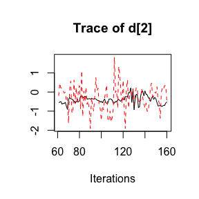

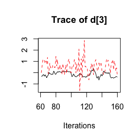

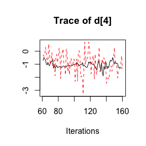

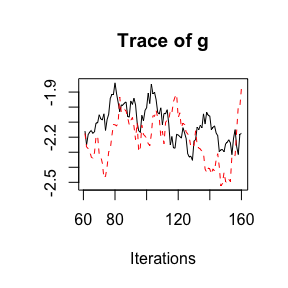

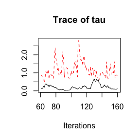

```r
coda::traceplot(jagsfit4$samples)
```

## 4.4 Bias-adjusted model 2

**Set up JAGS model**

The arguments for `method.bias='adjust2'` are similar to the ones used before in `method.bias='adjust1'`. The only additional argument is `bias.covariate = c('year','year')` which indicates using the year of study publication to estimate the study-probability of bias. The bias probabilities will be linked to `year` through logistic model ( internally coded). For more details see (Verde 2020) and our extension in Section 2.4.

```r
# jags model: code+data
mod5 <- crosnma.model(prt.data=prt.data,
                   std.data=std.data,
                   trt=c('trt','trt'),
                   study=c('study','study'),
                   outcome=c('outcome','outcome'),
                   n='n',
                   design=c('design','design'),
                   reference='A',
                   trt.effect='random',
                   #---------- bias adjustment ----------
                   method.bias='adjust2',
                   bias=c('bias','bias'),
                   bias.type='add',
                   bias.effect='common',
                   bias.covariate = c('year','year'),#
                   #---------- assign a prior ----------
                   prior=list(tau.trt='dunif(0,3)',
                                 pi.high.rct='dbeta(5,1)',
                                 pi.low.rct='dbeta(1,20)',
                                 pi.high.nrs='dbeta(30,1)',
                                 pi.low.nrs='dbeta(1,2)'
                   )
)
```

**Run JAGS**

```r
# run jags
jagsfit5 <- crosnma.run(model=mod5,
                       n.adapt = 20,
                        n.iter=100,
                        n.burnin = 40,
                        thin=1,
                        n.chains=2)
```

```
#> NOTE: Stopping adaptation
```

**Output**

*Table of estimates*

```r
knitr::kable(summary(jagsfit5))
```

|  | Mean | SD | 2.5% | 50% | 97.5% | Rhat | n.eff |
| --- | --- | --- | --- | --- | --- | --- | --- |
| d.A | 1.000 | 1.000 | 1.000 | 1.000 | 1.000 | NaN | 0 |
| d.B | 0.912 | 1.703 | 0.418 | 0.867 | 3.432 | 1.470 | 27 |
| d.C | 1.525 | 1.633 | 0.648 | 1.538 | 3.739 | 0.998 | 13 |
| d.D | 0.374 | 1.733 | 0.141 | 0.360 | 1.195 | 1.043 | 11 |
| g | 0.986 | 1.456 | 0.518 | 0.971 | 2.118 | 1.096 | 26 |
| tau | 0.973 | 0.365 | 0.492 | 0.868 | 1.771 | 1.478 | 17 |

*Trace plot of estimates*

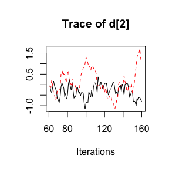

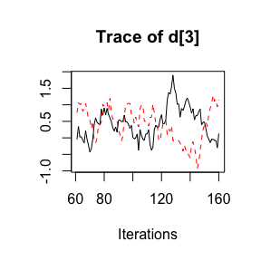

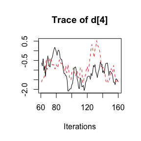

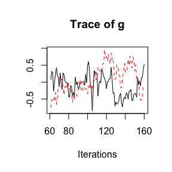

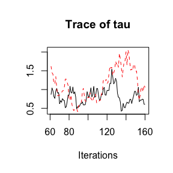

```r
coda::traceplot(jagsfit5$samples)
```

# References

Dias, Sofia, N. J. Welton, V. C. C. Marinho, G. Salanti, J.P.T Higgins, and A. E. Ades. 2010. “Estimation and Adjustment of Bias in Randomized Evidence by Using Mixed Treatment Comparison Meta-Analysis.” *Journal of the Royal Statistical Society* 173: 613–29.

Hamza T, Kuhle J, Pellegrini F. 2021. “Flexible Generic Framework for Evidence Synthesis in Health Technology Assessment.” *Unpublished*.

Plummer, Martyn. 2003. “JAGS: A Program for Analysis of Bayesian Graphical Models Using Gibbs Sampling.”

Verde, Pablo Emilio. 2020. “A Bias-Corrected Meta-Analysis Model for Combining, Studies of Different Types and Quality.” *Biometrical Journal. Biometrische Zeitschrift*, September. https://doi.org/10.1002/bimj.201900376.